# Water balance model (rasterbased)

Niranjan Wimalathunge

7/2/2021

## Introduction

The USYD Soil Water Balance Model (WBM) is a process-based model designed to address soil water dynamics across various depth supports and scalable farmscapes. This multi-layer, knowledge-based model enhances the representation of vertical soil moisture variation. Functioning as an unsaturated model, the WBM allows water to freely and continuously infiltrate through layers in accordance with soil properties determined by the Soil Landscape Grid of Australia (SLGA). The model’s layer thickness is defined by SLGA depth intervals. To calculate the saturated volumetric moisture content (θs), corresponding clay, sand, and bulk density values are employed. This calculation is carried out using a pedotransfer function (PTF) developed by Padarian et al. (2014).

The soil is assumed to be uniform within each horizontal layer, with water flowing vertically through these layers. As a result, infiltration occurs continuously across all layers, and any excess soil water beyond the 60–100 cm layer is considered deep drainage, lost to the system given the modeling depth of 1m (root zone). Additionally, runoff is assumed to occur only when Layer 0–5 cm and Layer 5–15 cm become saturated.

The model runs daily on each SLGA raster cell, incorporating the corresponding values for rainfall and evapotranspiration (ET). ET is extracted in layers: first from layer one, and if a deficit persists, it is then drawn from layer 2. This process continues sequentially through subsequent layers. This approach mirrors the general behavior of water extraction by the root systems of crops.

### Getting Started

```r
# load required libraries
library(raster)
library(RCurl)
library(rgdal)
library(sp)
library(sf)
library(viridis)
library(mapview)
```

## An example

### Area of interest (Llara)

```r
#Llara farm extent
Llara <- readOGR('X:/PRJ-SoilWaterNow/data/Aus/Farms&sites/Llara/Llarashapefile/Farm_boundary_new.shp')
```

```r
Llara<-spTransform(Llara,CRS("+proj=longlat +datum=WGS84"))
names(Llara)<-"Llara"
mapview(Llara, legend=F)
```

[interactive chart not shown]

### Get data

Use the [link](https://github.com/niranman/Water-Balance-Raster-Based) to download the datasets and change the file paths accordingly

### Model Inputs

The model inputs derive from 8-day ET (MODIS 500 m), daily rainfall (SILO 5 km ) and soil (SLGA 90 m), which can be freely downloadable. This tutorial shows as an example to show how to estimate soil water for an area of interest using the model.

ET: 8-day ET convert to daily assuming ET is uniform and resample to 90 m to match with the SLGA soil data rain: resample to 90 m to match with the SLGA soil data theta: Clay, Silt, Sand, and Bulk density layers

Model run:from 01-01-2016 to 31-12-2021

```r
ET <- brick("C:/Users/nman2690/OneDrive - The University of Sydney (Staff)/Llara/LlaraWB/LlaraET01-21_90m.tif")[[5479:7670]]
rain <- brick("C:/Users/nman2690/OneDrive - The University of Sydney (Staff)/Llara/LlaraWB/LlaraRain01-21_90m.tif")[[5479:7670]]
theta <- brick("C:/Users/nman2690/OneDrive - The University of Sydney (Staff)/Llara/LlaraWB/LlaraSoil.tif")
```

### Bucket size

The field capacity (drained upper limit (DUL))

```r
names(theta)[1:20]<-c( "BDW_005","BDW_015","BDW_030","BDW_060","BDW_100",
                       "CLY_005","CLY_015","CLY_030","CLY_060","CLY_100",
                       "SLT_005","SLT_015","SLT_030","SLT_060","SLT_100",
                       "SND_005","SND_015","SND_030","SND_060","SND_100")
fc_005 = 0.4795 - 3.873 * 10^-5 * theta$SND_005 ^2 - 6.701 * 10^-7 * theta$CLY_005 ^2 * theta$SND_005
fc_015 = 0.4795 - 3.873 * 10^-5 * theta$SND_015 ^2 - 6.701 * 10^-7 * theta$CLY_015 ^2 * theta$SND_015
fc_030 = 0.4795 - 3.873 * 10^-5 * theta$SND_030 ^2 - 6.701 * 10^-7 * theta$CLY_030 ^2 * theta$SND_030
fc_060 = 0.4795 - 3.873 * 10^-5 * theta$SND_060 ^2 - 6.701 * 10^-7 * theta$CLY_060 ^2 * theta$SND_060
fc_100 = 0.4795 - 3.873 * 10^-5 * theta$SND_100 ^2 - 6.701 * 10^-7 * theta$CLY_100 ^2 * theta$SND_100
```

Permanent wilting point (crop lower limit (CLL))

```r
pwp_005 = -0.1554 - 0.7221 * tanh(0.5 * (-0.9705 - 0.8529 * theta$BDW_005 - 0.00827 *theta$CLY_005 + 0.01994 * theta$SND_005))  + 0.1325 * tanh(0.5 * (3.71 - 3.19 * theta$BDW_005+ 0.01205 * theta$CLY_005 + 0.01617 * theta$SND_005)) + 0.1720 * tanh(0.5 * (-3.94 - 0.5067 * theta$BDW_005 + 0.02158 * theta$CLY_005 + 0.04978 * theta$SND_005))

pwp_015 = -0.1554 - 0.7221 * tanh(0.5 * (-0.9705 - 0.8529 * theta$BDW_015 - 0.00827 *theta$CLY_015 + 0.01994 * theta$SND_015))  + 0.1325 * tanh(0.5 * (3.71 - 3.19 * theta$BDW_015+ 0.01205 * theta$CLY_015 + 0.01617 * theta$SND_015)) + 0.1720 * tanh(0.5 * (-3.94 - 0.5067 * theta$BDW_015 + 0.02158 * theta$CLY_015 + 0.04978 * theta$SND_015))

pwp_030 = -0.1554 - 0.7221 * tanh(0.5 * (-0.9705 - 0.8529 * theta$BDW_030 - 0.00827 *theta$CLY_030 + 0.01994 * theta$SND_030))  + 0.1325 * tanh(0.5 * (3.71 - 3.19 * theta$BDW_030+ 0.01205 * theta$CLY_030 + 0.01617 * theta$SND_030)) + 0.1720 * tanh(0.5 * (-3.94 - 0.5067 * theta$BDW_030 + 0.02158 * theta$CLY_030 + 0.04978 * theta$SND_030))

pwp_060 = -0.1554 - 0.7221 * tanh(0.5 * (-0.9705 - 0.8529 * theta$BDW_060 - 0.00827 *theta$CLY_060 + 0.01994 * theta$SND_060))  + 0.1325 * tanh(0.5 * (3.71 - 3.19 * theta$BDW_060+ 0.01205 * theta$CLY_060 + 0.01617 * theta$SND_060)) + 0.1720 * tanh(0.5 * (-3.94 - 0.5067 * theta$BDW_060 + 0.02158 * theta$CLY_060 + 0.04978 * theta$SND_060))

pwp_100 = -0.1554 - 0.7221 * tanh(0.5 * (-0.9705 - 0.8529 * theta$BDW_100 - 0.00827 *theta$CLY_100 + 0.01994 * theta$SND_100))  + 0.1325 * tanh(0.5 * (3.71 - 3.19 * theta$BDW_100+ 0.01205 * theta$CLY_100 + 0.01617 * theta$SND_100)) + 0.1720 * tanh(0.5 * (-3.94 - 0.5067 * theta$BDW_100 + 0.02158 * theta$CLY_100 + 0.04978 * theta$SND_100))

pwp_bucketSize <-stack(pwp_005*50,pwp_015*100,pwp_030*150,pwp_060*300,pwp_100*400)
names(pwp_bucketSize)[1:5]<-c("pwp_005","pwp_015","pwp_030","pwp_060","pwp_100")
```

The minimum soil water in surface layers (0-5, 5-15 cm) determine by the residual moisture content

```r
# Residual Theta
resid_005<- (0.3697 *tanh (-0.0167 * theta$CLY_005 - 0.0259 * theta$SND_005 + 0.5587 * theta$BDW_005 + 1.86) -
               0.2543 *tanh (-0.0074 * theta$CLY_005 - 0.0061 * theta$SND_005 + 0.9869 * theta$BDW_005 - 1.47) -
               0.2099* tanh (-0.0653 * theta$CLY_005 - 0.0063 * theta$SND_005 - 5.3000 * theta$BDW_005 + 9.40) - 0.2032)^2

resid_015<- (0.3697 *tanh (-0.0167 * theta$CLY_015 - 0.0259 * theta$SND_015 + 0.5587 * theta$BDW_015 + 1.86) -
               0.2543 *tanh (-0.0074 * theta$CLY_015 - 0.0061 * theta$SND_015 + 0.9869 * theta$BDW_015 - 1.47) -
               0.2099* tanh (-0.0653 * theta$CLY_015 - 0.0063 * theta$SND_015 - 5.3000 * theta$BDW_015 + 9.40) - 0.2032)^2
resid_bucket<-stack(resid_005*50,resid_015*100)

# Bucket size for each soil layers
bucketSize <-stack((fc_005-resid_005)*50,(fc_015-resid_015)*100,(fc_030-pwp_030)*150,
                   (fc_060-pwp_060)*300,(fc_100-pwp_100)*400)

# water not access to plants
ResRootzone<-resid_005*50+resid_015*100+pwp_030*150+pwp_060*300+pwp_100*400
ResTopsoil<-resid_005*50+resid_015*100+pwp_030*150
```

### The water balance

```r
# 1- current day ; 2-previous day
# For example, SMA1(0-5 cm) means  today's soil moisture for 0-5 cm layer whereas SMA2 is previous day soil moisture for 0-5 cm layer
SM=raster(ET);SM=setValues(SM,0)
SMA1=SM;SMA2=SM;SMA3=SM
SMB1=SM;SMB2=SM;SMB3=SM
SMC1=SM;SMC2=SM;SMC3=SM
SMD1=SM;SMD2=SM;SMD3=SM
SME1=SM;SME2=SM;SME3=SM
runoff=SM; DeepD=SM
SM100total=stack();SM30total=stack()
SM30paw=stack();SM100paw=stack()
ETd=SM # deficit ET

for(a in 1:dim(ET)[3]){

  #layer 0-5 cm
  SMA2=SMA1*.8
  SMA1=SMA1*.2

  SMA1= SMA1+rain[[a]]-(ET[[a]])*0.125

  ETd<- overlay(SMA1,ETd, fun = function(x,y) {i <- x > 0 ;y[i] <- 0;return(y)})
  ETd<- overlay(SMA1,ETd, fun = Vectorize(function(x,y) {i <- x < 0 ;y[i] <- -x;return(y)}))
  SMA1<-calc(SMA1, fun=function(x){ x[x < 0] <- 0; return(x)} )

  SMB1<- overlay(SMA1,SMB1,bucketSize[[1]], fun = Vectorize(function(x, y, z) {i <- x > z ;y[i] <- y[i] + (x[i]-z[i]);return(y)}))
  SMA1<- overlay(SMA1,SMB1,bucketSize[[1]], fun = Vectorize(function(x, y, z) {i <- x > z ;x[i] <- z[i];return(x)}))

  #layer 5-15 cm
  SMB2=SMB1*.05
  SMB1=SMB1*.95

  SMB1 = SMB1+SMA2-ETd

  ETd<- overlay(SMB1,ETd, fun = Vectorize(function(x,y) {i <- x > 0 ;y[i] <- 0;return(y)}))
  ETd<- overlay(SMB1,ETd, fun = Vectorize(function(x,y) {i <- x < 0 ;y[i] <- -x;return(y)}))
  SMB1<-calc(SMB1, fun=function(x){ x[x < 0] <- 0; return(x)})

  # if layer 1 and layer 2 full then runoff is the offset of the layer2
  runoff<-overlay(SMA1,SMB1,bucketSize[[1]], bucketSize[[2]],runoff,fun=Vectorize(function(x,y,z,v,w){i<-x==z & y>v;w[i]<-y[i]-v[i];return(w)}))
  SMB1<-overlay(SMB1,SMC1,bucketSize[[2]], fun=Vectorize(function(x,y,z){i<-x>z;x[i]<-z[i];return(x)}))

  # else
  SMC1<-overlay(SMB1,SMC1,bucketSize[[2]], fun=Vectorize(function(x,y,z){i<-x>z;y[i]<-y[i]+(x[i]-z[i]);return(y)}))
  SMB1<-overlay(SMB1,SMC1,bucketSize[[2]], fun=Vectorize(function(x,y,z){i<-x>z;x[i]<-z[i];return(x)}))


  #layer 15-30 cm
  SMC2=SMC1*.05
  SMC1=SMC1*.95

  SMC1 = SMC1+SMB2-ETd

  ETd<- overlay(SMC1,ETd, fun = Vectorize(function(x,y) {i <- x > 0 ;y[i] <- 0;return(y)}))
  ETd<- overlay(SMC1,ETd, fun = Vectorize(function(x,y) {i <- x < 0 ;y[i] <- -x;return(y)}))
  SMC1<-calc(SMC1, fun=function(x){ x[x < 0] <- 0; return(x)})

  SMD1<-overlay(SMC1,SMD1,bucketSize[[3]],fun=Vectorize(function(x,y,z){i<-x>z;y[i]<-y[i]+(x[i]-z[i]);return(y)}))
  SMC1<-overlay(SMC1,SMD1,bucketSize[[3]],fun=Vectorize(function(x,y,z){i<-x>z;x[i]<-z[i];return(x)}))

  #layer 30-60 cm
  SMD2=SMD1*.01
  SMD1=SMD1*.99

  SMD1 = SMD1+ SMC2-ETd

  ETd<- overlay(SMD1,ETd, fun = Vectorize(function(x,y) {i <- x > 0 ;y[i] <- 0;return(y)}))
  ETd<- overlay(SMD1,ETd, fun = Vectorize(function(x,y) {i <- x < 0 ;y[i] <- -x;return(y)}))
  SMD1<-calc(SMD1, fun=function(x){ x[x < 0] <- 0; return(x)})

  SME1<-overlay(SMD1,SME1,bucketSize[[4]],fun=Vectorize(function(x,y,z){i<-x>z;y[i]<-y[i]+(x[i]-z[i]);return(y)}))
  SMD1<-overlay(SMD1,SME1,bucketSize[[4]],fun=Vectorize(function(x,y,z){i<-x>z;x[i]<-z[i];return(x)}))

  #layer 60-100 cm
  SME2=SME1*.01
  SME1=SME1*.99

  SME1 = SME1+ SMD2-ETd

  ETd<- overlay(SME1,ETd, fun = Vectorize(function(x,y) {i <- x > 0 ;y[i] <- 0;return(y)}))
  ETd<- overlay(SME1,ETd, fun = Vectorize(function(x,y) {i <- x < 0 ;y[i] <- -x;return(y)}))
  SME1<-calc(SME1, fun=function(x){ x[x < 0] <- 0; return(x)})

  DeepD<-overlay(SME1,DeepD,bucketSize[[5]],fun=Vectorize(function(x,y,z){i<-x>z;y[i]<-y[i]+(x[i]-z[i]);return(y)}))
  SME1<-overlay(SME1,DeepD,bucketSize[[5]],fun=Vectorize(function(x,y,z){i<-x>z;x[i]<-z[i];return(x)}))

  #select either Total water or Paw water and save
  #SM30total=stack(SM30total,(SMA1+SMB1+SMC1+ResTopsoil))# Total water
  #SM100total=stack(SM100total,(SMA1+SMB1+SMC1+SMD1+SME1+ResRootzone))# Total water

  SM30paw=stack(SM30paw,(SMA1+SMB1+SMC1))# Plant available water
  SM100paw=stack(SM100paw,(SMA1+SMB1+SMC1+SMD1+SME1))# plant available water

  runoff=setValues(runoff, 0)
  DeepD=setValues(DeepD, 0)
  ETd=setValues(ETd,0)
  a=a+1
}
```

### Save rasters

```r
writeRaster(SM100paw, filename='X:/PRJ-SoilWaterNow/data/Aus/Farms&sites/Llara/SM100paw(2016-2021).tif', format="GTiff", overwrite=TRUE,options=c("INTERLEAVE=BAND","COMPRESS=LZW"))
writeRaster(SM30paw, filename='X:/PRJ-SoilWaterNow/data/Aus/Farms&sites/Llara/SM100paw(2016-2021).tif', format="GTiff", overwrite=TRUE,options=c("INTERLEAVE=BAND","COMPRESS=LZW"))
```

### Plot soil water

Important dates which you need soil water conditions For example, 1st April 2021: the start of the crops 1st July 2021: full-grown crop

Topsoil(0-30cm),Subsoil(30-100), and Rootzone (0-100 cm)

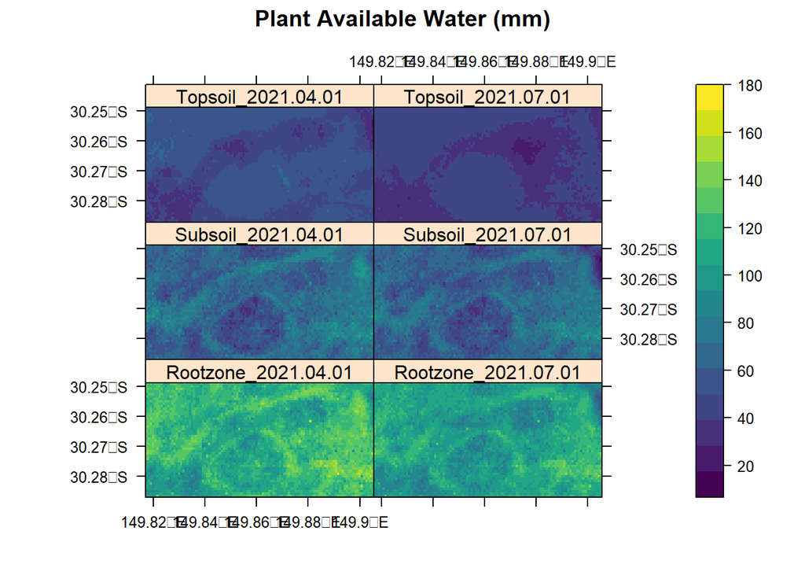

```r
names(SM30paw)<-paste("Topsoil", seq(from=as.Date('2016-01-01'), to=as.Date("2021-12-31"),by='days' ), sep = "_")
Topsoil<-SM30paw[[grep("2021.04.01|2021.07.01",names(SM30paw))]]

names(SM100paw)<-paste("Rootzone", seq(from=as.Date('2016-01-01'), to=as.Date("2021-12-31"),by='days' ), sep = "_")
Rootzone<-SM100paw[[grep("2021.04.01|2021.07.01",names(SM100paw))]]

Subsoil=SM100paw-SM30paw
names(Subsoil)<-paste("Subsoil", seq(from=as.Date('2016-01-01'), to=as.Date("2021-12-31"),by='days' ), sep = "_")
Subsoil<-Subsoil[[grep("2021.04.01|2021.07.01",names(Subsoil))]]

boundary.layer <- list("sp.lines", Llara, col = "green")
spplot(stack(Topsoil,Subsoil,Rootzone),sp.layout = boundary.layer,col.regions=viridis(100),main="Plant Available Water (mm)",scales = list(draw = TRUE))
```